# Diagnostics for Mixed and Multilevel GLMs

Rebecca Gill

2026-05-17

← Back to Index

This page is built in R Markdown. Most code chunks are hidden by default, but you can click ‘show’ to see the code that loads the libraries and generates the data, figures, and tables. The code is also available in my [studycourts/gradData GitHub repository](https://github.com/studycourts/gradData/tree/main/pages).

```r
P <- c(
  "knitr",          # rendering
  "kableExtra",     # table formatting
  "lme4",           # lmer(), glmer() — the workhorse mixed model package
  "ordinal",        # clmm() for ordinal mixed models
  "DHARMa",         # simulation-based residuals for GLMMs
  "performance",    # icc(), check_model(), check_convergence(), check_singularity(), r2()
  "ggeffects",      # ggpredict() for effect plots including random effects
  "patchwork",      # combining ggplots
  "RColorBrewer",   # expanding plot palettes
  "tidyverse"       # wrangling and ggplot2 — load last
)

for (pkg in P) {
  if (!require(pkg, character.only = TRUE)) {
    install.packages(pkg, repos = "http://cran.us.r-project.org")
  }
  library(pkg, character.only = TRUE)
}

rm(P, pkg)  # clean up the mess
```

```r
set.seed(1975)   # for reproducibility

# sim 1: random intercept binary GLMM

n.ctry   <- 30                                      # number of countries
n.cit    <- 50                                      # citizens per country
n.total  <- n.ctry * n.cit

country.id <- rep(seq_len(n.ctry), each = n.cit)   # country membership

# level-2 predictor: country-level Gini coefficient (standardized)
gini     <- rnorm(n.ctry, mean = 0, sd = 1)
gini.i   <- rep(gini, each = n.cit)                # expand to individual level

# true random intercepts (between-country variance = 0.8^2)
u.ctry   <- rnorm(n.ctry, mean = 0, sd = 0.8)
u.i      <- u.ctry[country.id]

# level-1 predictor: individual income (standardized)
income   <- rnorm(n.total, mean = 0, sd = 1)

# true fixed effects
eta      <- -0.3 + (-0.6) * income + 0.7 * gini.i + u.i
y.bin    <- rbinom(n.total, 1, plogis(eta))         # binary support outcome

bin.df <- data.frame(
  y       = y.bin,
  income  = income,
  gini    = gini.i,
  country = factor(country.id)
)

# null model (random intercept only — for ICC)
null.glmm <- lme4::glmer(
  y ~ 1 + (1 | country),
  data   = bin.df,
  family = binomial(link = "logit")
)

# full model (fixed effects + random intercept)
full.glmm <- lme4::glmer(
  y ~ income + gini + (1 | country),
  data   = bin.df,
  family = binomial(link = "logit")
)

# sim 2: random slope model

u.slope  <- MASS::mvrnorm(
  n.ctry,
  mu    = c(0, 0),
  Sigma = matrix(c(0.64, -0.15, -0.15, 0.09), 2, 2)  # correlated intercept + slope
)

u.int.rs   <- u.slope[, 1]                         # random intercepts
u.slope.rs <- u.slope[, 2]                         # random slopes for income

eta.rs  <- -0.3 +
           (-0.6 + u.slope.rs[country.id]) * income +
           0.7 * gini.i +
           u.int.rs[country.id]
y.rs    <- rbinom(n.total, 1, plogis(eta.rs))

rs.df   <- data.frame(
  y       = y.rs,
  income  = income,
  gini    = gini.i,
  country = factor(country.id)
)

# random intercept model (nested in random slope)
ri.rs.mod <- lme4::glmer(
  y ~ income + gini + (1 | country),
  data   = rs.df,
  family = binomial
)

# random slope model (correct specification)
rs.mod <- lme4::glmer(
  y ~ income + gini + (1 + income | country),
  data    = rs.df,
  family  = binomial,
  control = glmerControl(optimizer = "bobyqa",
                         optCtrl   = list(maxfun = 2e5))
)

# sim 3: gaussian multilevel model

n.sch    <- 25
n.stu    <- 40
n.tot.g  <- n.sch * n.stu

school.id  <- rep(seq_len(n.sch), each = n.stu)
u.sch      <- rnorm(n.sch, 0, 3.5)                 # school random intercepts
ses        <- rnorm(n.tot.g)                        # student SES (level 1)
class.size <- rep(rnorm(n.sch, 0, 1), each = n.stu)# class size (level 2)

score   <- 70 + 4 * ses - 2 * class.size +
           u.sch[school.id] + rnorm(n.tot.g, 0, 6) # level-1 residual
score   <- pmax(0, pmin(100, score))                # clip to [0,100]

gauss.df <- data.frame(
  score      = score,
  ses        = ses,
  class.size = class.size,
  school     = factor(school.id)
)

gauss.mod <- lme4::lmer(
  score ~ ses + class.size + (1 | school),
  data = gauss.df,
  REML = TRUE
)
```

## Introduction

Mixed models — also called multilevel or hierarchical models — are the appropriate tool whenever your data have a clustered structure: survey respondents nested within countries, students within schools, repeated observations on the same individual, roll-call votes within legislators. The clustering structure means that observations within the same group tend to be more similar to each other than to observations in other groups, and ignoring this dependence understates standard errors and overstates precision.

Diagnosing a mixed model requires attention to two levels simultaneously. At the **observation level** (level 1), you’re asking whether the fixed effects are correctly specified and whether individual observations fit the model well. At the **group level** (level 2), you’re asking whether the random effects structure is appropriate and whether any groups behave in ways the model doesn’t anticipate.

This page works through the full diagnostic workflow for mixed GLMs, starting with the question of whether a mixed model is warranted at all (via the ICC), moving through model-building decisions, and then covering the observation-level and group-level diagnostics that should accompany every fitted mixed model. The tools throughout are modern: DHARMa for simulation-based residuals, `performance` for a suite of model checks, and effect plots for communicating what the random effects are actually telling you.

The residuals page on this site covers the theoretical basis for quantile residuals and the DHARMa workflow in detail. This page applies those tools specifically to the mixed model context and adds the diagnostics that are unique to models with random effects.

## Is a Mixed Model Warranted? The ICC

The first question before you specify a mixed model is whether there’s enough clustering in the data to justify the additional complexity. The **intraclass correlation coefficient** (ICC) answers this by quantifying what fraction of the total variance in the outcome is attributable to the grouping structure.

For a **Gaussian** outcome, the ICC from the null model (random intercept only, no predictors) is:

$$\text{ICC} = \frac{\tau_{00}}{\tau_{00} + \sigma^2}$$

where $\tau_{00}$ is the between-group variance and $\sigma^2$ is the within-group (residual) variance.

For **binary and other non-Gaussian** outcomes estimated with a logit link, the level-1 variance is fixed by the distributional assumption rather than estimated from the data. For logistic models, the latent-variable level-1 variance is $\pi^2/3 \approx 3.29$. The ICC using the latent variable approach is:

$$\text{ICC} = \frac{\tau_{00}}{\tau_{00} + \pi^2/3}$$

```r
# ICC from the null GLMM (random intercept only)
# performance::icc() handles the latent variable formula for binary models automatically
performance::icc(null.glmm)
```

```
## # Intraclass Correlation Coefficient
##
##     Adjusted ICC: 0.163
##   Unadjusted ICC: 0.163
```

```r
# look at the variance components directly
lme4::VarCorr(null.glmm)
```

```
##  Groups  Name        Std.Dev.
##  country (Intercept) 0.799
```

```r
# manual calculation for transparency
tau00 <- as.numeric(lme4::VarCorr(null.glmm)$country)
icc.val <- tau00 / (tau00 + (pi^2 / 3))

cat("Between-country variance (tau_00):", round(tau00, 4), "\n")
```

```
## Between-country variance (tau_00): 0.6391
```

```r
cat("ICC (latent variable formula):    ", round(icc.val, 3), "\n")
```

```
## ICC (latent variable formula):     0.163
```

The conventional rule of thumb is that an ICC above 0.05 suggests meaningful clustering, and above 0.10 strongly justifies a mixed model. But the threshold isn’t the whole story. If the clustering structure is theoretically motivated — if you have good reasons to believe that country context shapes individual outcomes — include the random effect even when the ICC is small. The cost of an unnecessary random effect (a small efficiency loss) is lower than the cost of ignoring real clustering (biased standard errors throughout the model).

> The ICC from the null model is also equivalent to the conditional $R^2$ from a model with no fixed effects — it tells you how much of the total outcome variance is explained by group membership alone, before any individual-level predictors are included.

## Building the Random Effects Structure

### Random Intercept vs. Random Slope

The most common mixed model specification is the **random intercept model**: groups vary in their baseline level of the outcome, but the effect of every predictor is assumed to be the same across groups. When theoretical reasoning suggests that a predictor’s effect might vary across contexts — income inequality having different effects on redistribution preferences in different countries, a treatment having different effects in different schools — a **random slope** model is appropriate.

Use a likelihood ratio test to compare the random intercept model to the random slope model:

```r
# LRT: random intercept vs. random slope
# H0: the slope for income does not vary across countries
anova(ri.rs.mod, rs.mod, refit = FALSE)
```

```
## Data: rs.df
## Models:
## ri.rs.mod: y ~ income + gini + (1 | country)
## rs.mod: y ~ income + gini + (1 + income | country)
##           npar  AIC  BIC logLik -2*log(L) Chisq Df Pr(>Chisq)
## ri.rs.mod    4 1793 1814   -893      1785
## rs.mod       6 1792 1824   -890      1780  4.65  2      0.098 .
## ---
## Signif. codes:  0 '***' 0.001 '**' 0.01 '*' 0.05 '.' 0.1 ' ' 1
```

A significant result means the random slope improves fit — the effect of income genuinely varies across countries in ways that matter for inference. A non-significant result means the random intercept is sufficient and the added complexity of the slope isn’t supported by the data.

Should I always test for random slopes on every predictor?

No — and doing so can lead to overfitting and convergence problems. Test random slopes only for predictors where you have a theoretical reason to believe the effect varies across groups. Random slopes for all level-1 predictors is sometimes called the “maximal model” approach, and while it’s defensible in some contexts, it often produces singular fits or convergence warnings in the sample sizes typical of political science research. Let theory guide the random effects structure, and use the LRT to confirm.

### Interpreting the Variance Components

The `lme4::VarCorr()` function gives you the estimated variance components for any fitted model. Knowing how to read these is essential:

```r
# variance components from the random slope model
lme4::VarCorr(rs.mod)
```

```
##  Groups  Name        Std.Dev. Corr
##  country (Intercept) 0.770
##          income      0.261    -0.03
```

## Observation-Level Diagnostics

### Quantile Residuals via DHARMa

The primary tool for observation-level diagnostics in mixed GLMs is DHARMa (Hartig 2022). As discussed in the residuals page, DHARMa generates simulation-based quantile residuals by simulating new response vectors from the fitted model and computing where each observed value falls in its simulated distribution. For GLMMs, this simulation automatically marginalizes over the random effects, producing residuals that are valid at the observation level regardless of the distributional family.

Figure 1: DHARMa quantile residuals for the full binary GLMM. The QQ plot (left) should show points near the diagonal under a well-specified model; the residual-vs-fitted plot (right) should show no systematic pattern.

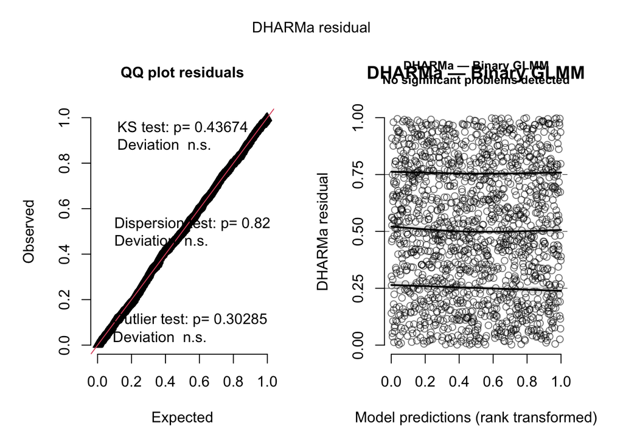

```r
sim.glmm <- DHARMa::simulateResiduals(full.glmm, n = 500, plot = FALSE)
plot(sim.glmm, main = "DHARMa — Binary GLMM")
```

Run the standard suite of formal tests on the DHARMa residuals:

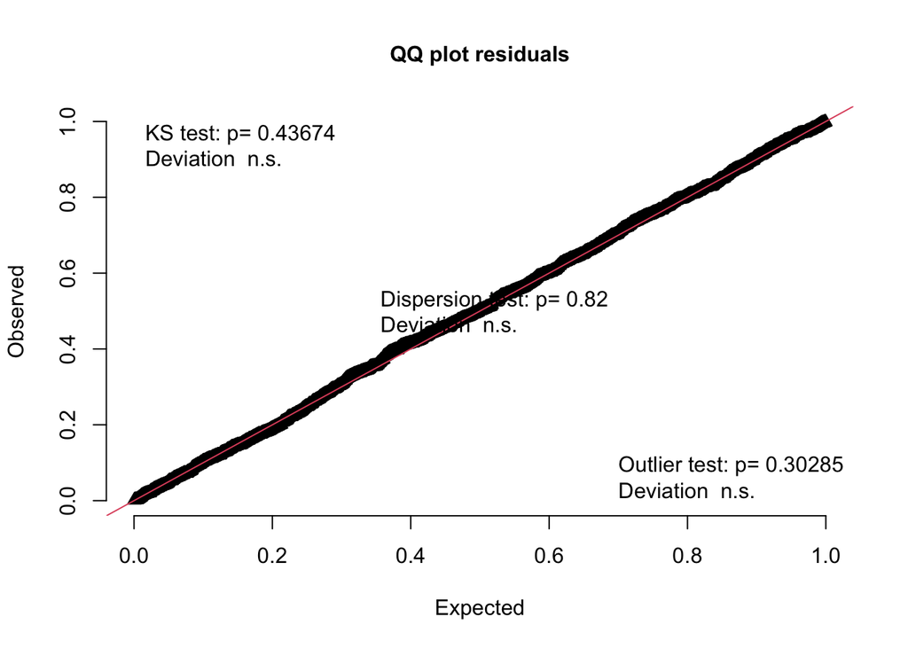

```
##
##  Asymptotic one-sample Kolmogorov-Smirnov test
##
## data:  simulationOutput$scaledResiduals
## D = 0.022, p-value = 0.4
## alternative hypothesis: two-sided
```

```r
DHARMa::testUniformity(sim.glmm)
```

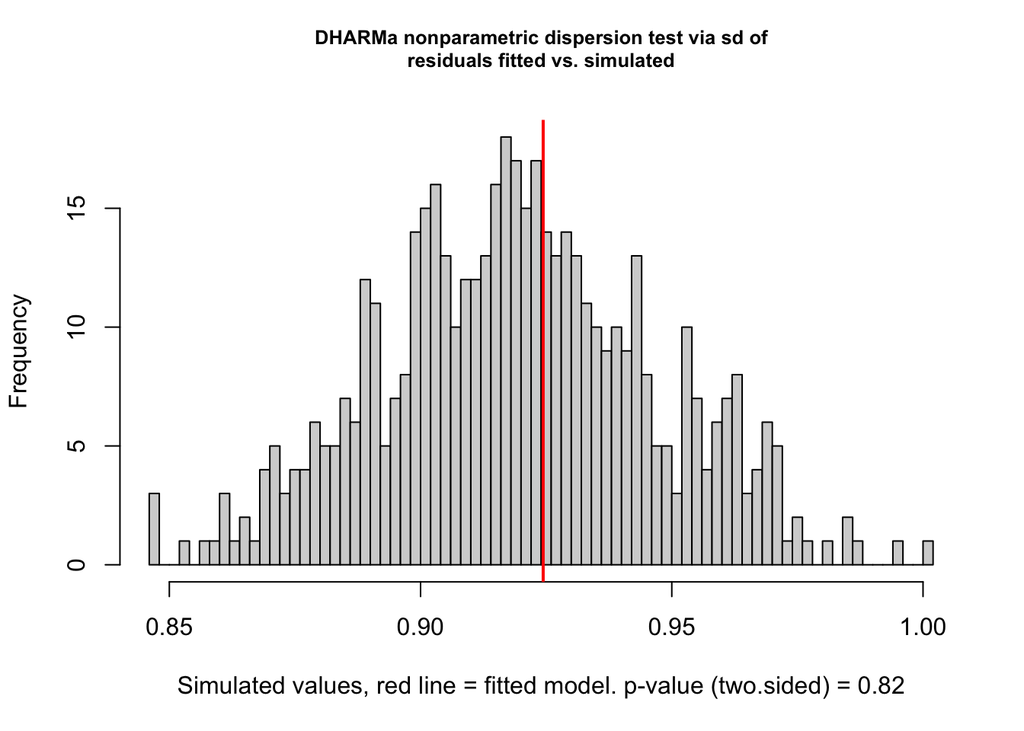

```
##
##  DHARMa nonparametric dispersion test via sd of residuals fitted vs.
##  simulated
##
## data:  simulationOutput
## dispersion = 1, p-value = 0.8
## alternative hypothesis: two.sided
```

```r
DHARMa::testDispersion(sim.glmm)
```

```r
DHARMa::testOutliers(sim.glmm, type = "bootstrap", nBoot = 100, plot = FALSE)
```

```
##
##  DHARMa bootstrapped outlier test
##
## data:  sim.glmm
## outliers at both margin(s) = 0, observations = 1500, p-value = 1
## alternative hypothesis: two.sided
##  percent confidence interval:
##  0 0
## sample estimates:
## outlier frequency (expected: 0 )
##                                0
```

Plot the DHARMa residuals against each predictor to check for nonlinearity at the individual level:

Figure 2: DHARMa residuals against income (left) and Gini (right) for the binary GLMM. The smoother should track flat near 0.5 across the range of each predictor.

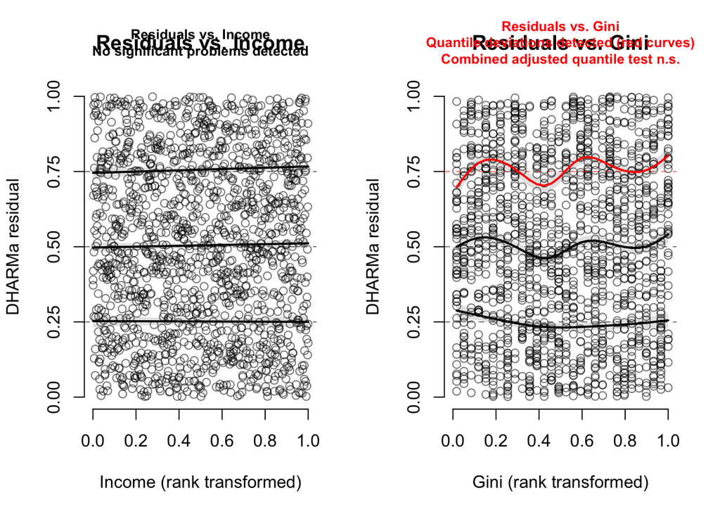

```r
par(mfrow = c(1, 2))
DHARMa::plotResiduals(sim.glmm, form = bin.df$income,
                      xlab = "Income", main = "Residuals vs. Income")
DHARMa::plotResiduals(sim.glmm, form = bin.df$gini,
                      xlab = "Gini", main = "Residuals vs. Gini")
```

### Outliers at the Observation Level

`performance::check_outliers()` handles lme4 model objects and applies Cook’s D and leverage diagnostics at the observation level:

```r
# observation-level outlier check
perf.out <- performance::check_outliers(full.glmm)
print(perf.out)
```

```
## OK: No outliers detected.
## - Based on the following method and threshold: cook (0.7).
## - For variable: (Whole model)
```

For any flagged observations, follow the same sequence described in the outliers and nonlinearity page: check which coefficients are affected via DFBETAS, compare the model with and without the flagged observation, and ask substantively why the observation is unusual.

## Group-Level Diagnostics

### QQ Plot of Random Effects (BLUPs)

The model assumes that the group-level random effects are drawn from a normal distribution with mean zero: $u_j \sim N(0, \tau_{00})$. The estimated random effects — called **BLUPs** (Best Linear Unbiased Predictors) or **conditional modes** — should be approximately normally distributed. A QQ plot of the BLUPs is the standard check:

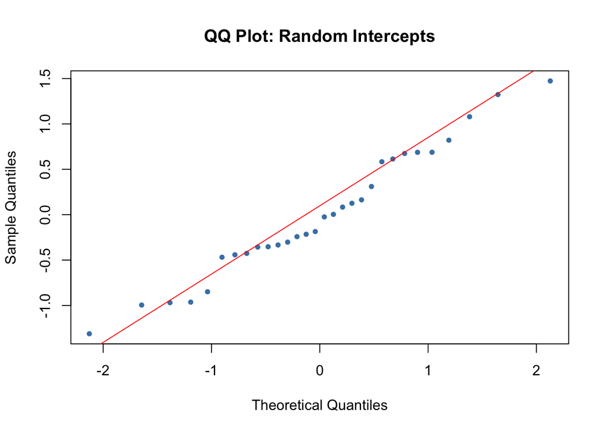

```r
# extract random effects
re.vals <- lme4::ranef(full.glmm)$country

# QQ plot
qqnorm(re.vals[, "(Intercept)"],
       main = "QQ Plot: Random Intercepts",
       pch  = 20, col = "steelblue")
qqline(re.vals[, "(Intercept)"], col = "red")
```

The BLUPs are being shrunk toward zero by the model. Won’t they always look approximately normal because of that shrinkage?

Yes, and this is an important caveat. The mixed model’s partial pooling mechanism shrinks BLUPs toward the grand mean, which tends to make their empirical distribution look more normal than the true distribution of random effects. Mild deviations in the center of the QQ plot are therefore not very informative — the shrinkage will produce apparent normality there regardless. Pay attention to the **tails**: systematic deviations from the reference line in the extremes are more meaningful, because the groups with the most extreme BLUPs are the ones for which the model has the most data and the least shrinkage (Bates et al. 2015).

### Group-Level Residuals from DHARMa

Aggregating DHARMa residuals to the group level reveals whether any groups are systematically mispredicted. Groups with mean residuals far from 0.5 (the expected value on the uniform scale) are behaving unusually relative to the model’s predictions:

Figure 4: Mean DHARMa residual by country (sorted). Under a well-specified model, the group means should be scattered uniformly near 0.5 with no strong outliers. Values near 0 or near 1 indicate groups that the model systematically over- or under-predicts.

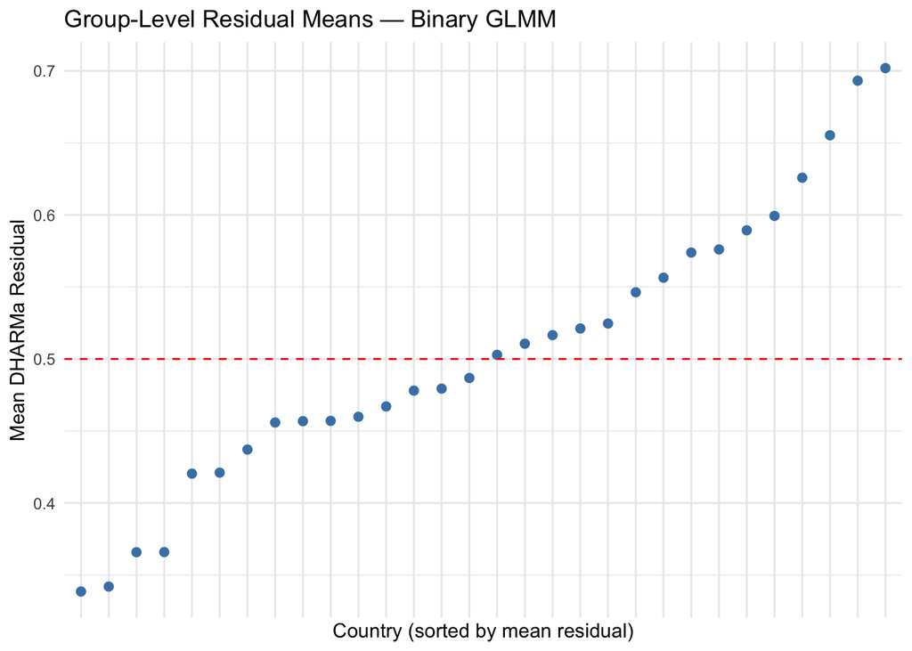

```r
# DHARMa residuals are on the uniform (0,1) scale internally
bin.df$dharma.resid <- residuals(sim.glmm)

# aggregate to country level
group.resid <- bin.df %>%
  group_by(country) %>%
  summarise(
    mean.resid = mean(dharma.resid, na.rm = TRUE),
    n          = n()
  )

ggplot(group.resid, aes(x = reorder(country, mean.resid),
                         y = mean.resid)) +
  geom_point(color = "steelblue", size = 2) +
  geom_hline(yintercept = 0.5, linetype = "dashed", color = "red") +
  labs(x     = "Country (sorted by mean residual)",
       y     = "Mean DHARMa Residual",
       title = "Group-Level Residual Means — Binary GLMM") +
  theme_minimal() +
  theme(axis.text.x = element_blank())
```

### Caterpillar Plots: Visualizing the Random Effects

The **caterpillar plot** — a horizontal dot plot of the BLUP estimates with their confidence intervals, sorted by magnitude — is the standard visualization of random effects. It shows which groups deviate most from the grand mean, and whether their confidence intervals exclude zero (meaning their deviation is reliably estimated):

Figure 5: Caterpillar plot of country-level random intercepts. Each point is a BLUP estimate for one country; horizontal lines are 95% confidence intervals. Countries whose intervals exclude zero are reliably above or below the grand mean on the outcome.

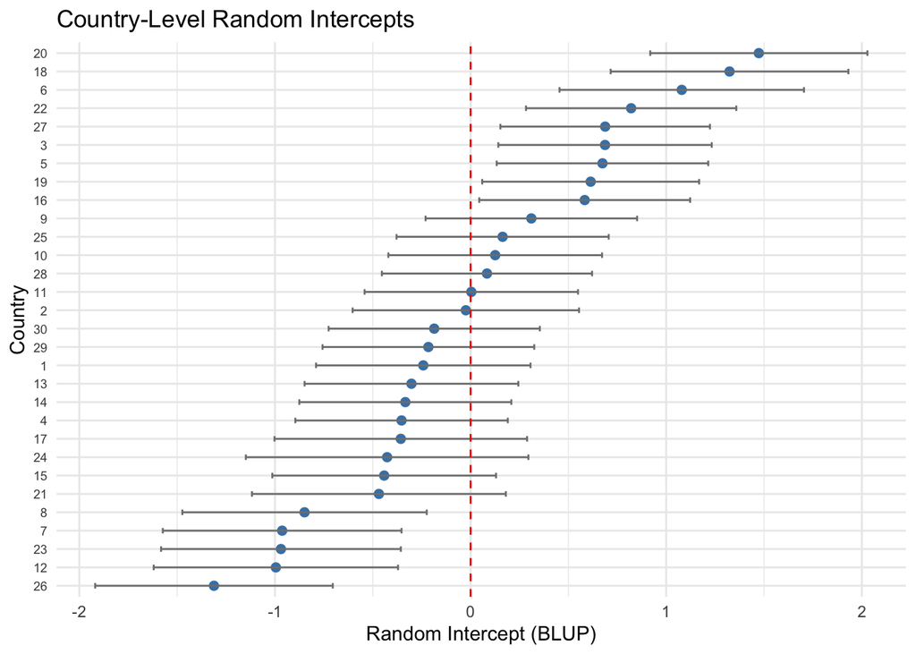

```r
# extract random effects with confidence intervals
re.df <- as.data.frame(lme4::ranef(full.glmm, condVar = TRUE))

ggplot(re.df, aes(x = reorder(grp, condval), y = condval)) +
  geom_point(color = "steelblue", size = 2) +
  geom_errorbar(aes(ymin = condval - 1.96 * condsd,
                    ymax = condval + 1.96 * condsd),
                width = 0.3, color = "grey50") +
  geom_hline(yintercept = 0, linetype = "dashed", color = "red") +
  coord_flip() +
  labs(x     = "Country",
       y     = "Random Intercept (BLUP)",
       title = "Country-Level Random Intercepts") +
  theme_minimal() +
  theme(axis.text.y = element_text(size = 7))
```

Groups with very wide confidence intervals are those where the model is uncertain about the random effect — usually small groups with few observations. Groups with narrow intervals that don’t cross zero are the ones most clearly distinguishable from the grand mean.

## Understanding What the Random Effects Are Telling You

Getting the diagnostics right is only half the job. The other half is interpreting what the random effects structure is actually saying about your data. This is where mixed models are often underexplained in applied write-ups — authors report the variance components but don’t translate them into substantive language.

### The Variance Partition

The variance components from `VarCorr()` tell you how variance in the outcome is partitioned across levels. For the Gaussian test score example, this is most transparent:

```r
# variance components from the Gaussian model
vc.gauss <- as.data.frame(lme4::VarCorr(gauss.mod))
vc.gauss
```

```
##        grp        var1 var2  vcov sdcor
## 1   school (Intercept) <NA> 14.55 3.815
## 2 Residual        <NA> <NA> 35.99 5.999
```

```r
# calculate percentage of variance at each level
total.var <- sum(vc.gauss$vcov)
vc.gauss %>%
  mutate(pct_variance = round(100 * vcov / total.var, 1)) %>%
  select(grp, var1, vcov, pct_variance) %>%
  kable(col.names = c("Group", "Component", "Variance", "% of Total"),
        caption   = "Variance partition: school-level and residual variance") %>%
  kable_styling(bootstrap_options = c("striped", "hover"),
                full_width = FALSE)
```

Table 1: Table 2: Variance partition: school-level and residual variance

| Group | Component | Variance | % of Total |
| --- | --- | --- | --- |
| school | (Intercept) | 14.55 | 28.8 |
| Residual |  | 35.99 | 71.2 |

The percentage of variance at the school level (after accounting for SES and class size) is the **conditional ICC** — how much clustering remains once the fixed effects have been included. Compare this to the unconditional ICC from the null model to see how much of the between-school variance your predictors explain.

### Interpreting Random Slopes

When your model includes a random slope, the slope variance $\tau_{11}$ tells you how much the effect of a predictor varies across groups. But a variance is hard to communicate to a reader. The most effective approach is to visualize the random slopes directly:

Figure 6: Predicted probability of redistribution support as a function of income by country.

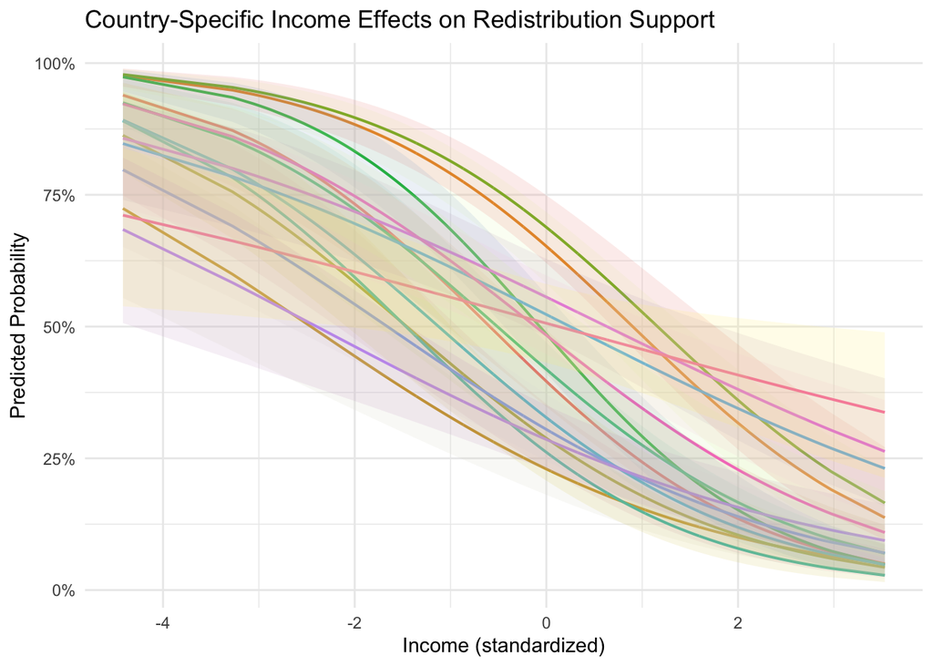

```r
# predicted values for each country across the range of income
income.range <- seq(-2.5, 2.5, length.out = 50)

# country-level predictions using ggpredict with the random effects
re.preds <- ggeffects::ggpredict(rs.mod,
                                  terms    = c("income [all]", "country [sample=15]"),
                                  type     = "random",
                                  ci.level = NA)   # suppress CIs for clarity

colorz <- colorRampPalette(brewer.pal(12, "Set3"))(15)

plot(re.preds) +
  labs(title = "Country-Specific Income Effects on Redistribution Support",
       x     = "Income (standardized)",
       y     = "Predicted Probability") +
  theme_minimal() +
  scale_fill_manual(values = colorz) +
  theme(legend.position = "none")
```

### The Correlation Between Random Intercepts and Slopes

```r
# extract the correlation between random intercepts and slopes
re.corr <- attr(lme4::VarCorr(rs.mod)$country, "correlation")
cat("Correlation between random intercepts and income slopes:\n")
```

```
## Correlation between random intercepts and income slopes:
```

```r
print(round(re.corr, 3))
```

```
##             (Intercept) income
## (Intercept)       1.000 -0.027
## income           -0.027  1.000
```

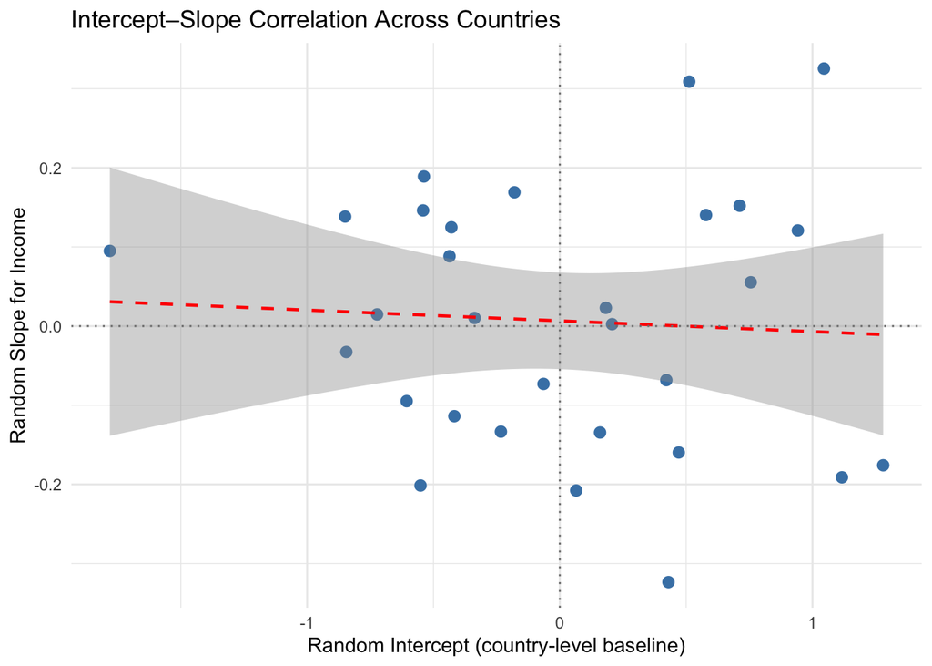

```r
# scatterplot of BLUPs: intercepts vs. slopes
re.rs.df <- as.data.frame(lme4::ranef(rs.mod)$country)
names(re.rs.df) <- c("intercept", "income_slope")
re.rs.df$country <- rownames(re.rs.df)

ggplot(re.rs.df, aes(x = intercept, y = income_slope)) +
  geom_point(color = "steelblue", size = 2.5) +
  geom_smooth(method = "lm", se = TRUE, color = "red",
              linetype = "dashed", linewidth = 0.8) +
  geom_hline(yintercept = 0, linetype = "dotted", color = "grey50") +
  geom_vline(xintercept = 0, linetype = "dotted", color = "grey50") +
  labs(x     = "Random Intercept (country-level baseline)",
       y     = "Random Slope for Income",
       title = "Intercept–Slope Correlation Across Countries") +
  theme_minimal()
```

## Heterogeneity Bias: The Mundlak Correction

One diagnostic issue specific to mixed models — and one that’s easy to miss — is **heterogeneity bias**, also called the **unit heterogeneity problem** or the “ecological fallacy” problem in multilevel form.

It arises when a level-1 predictor is correlated with the group-level random effect. For example, suppose wealthier individuals are more likely to live in wealthier countries. If being in a wealthier country also independently affects redistribution preferences (through a channel you haven’t modeled), then the individual-level income coefficient will be confounded by the country-level income composition — the within-country effect of income is contaminated by between-country differences in income levels.

The **Mundlak correction** (Mundlak 1978) addresses this by adding the group mean of each level-1 predictor as an additional level-2 covariate. If the group mean’s coefficient is significant, heterogeneity bias is present and should be accounted for. The corrected model separates the within-group effect (individual income, group-mean-centered) from the between-group effect (the group mean itself):

```r
# compute country-mean of income (the Mundlak correction variable)
bin.df <- bin.df %>%
  group_by(country) %>%
  mutate(income.ctry.mn = mean(income)) %>%   # country mean of income
  ungroup() %>%
  mutate(income.within = income - income.ctry.mn)  # within-country deviation

# Mundlak-corrected model: add country mean of income as a fixed effect
mundlak.mod <- lme4::glmer(
  y ~ income.within + income.ctry.mn + gini + (1 | country),
  data   = bin.df,
  family = binomial
)

# compare original and Mundlak models
# if income.ctry.mn is significant, heterogeneity bias is present in the original
summary(mundlak.mod)$coefficients[, c("Estimate", "Std. Error", "z value", "Pr(>|z|)")]
```

```
##                 Estimate Std. Error  z value                  Pr(>|z|)
## (Intercept)    -0.408072    0.15086 -2.70496 0.00683134062994660961471
## income.within  -0.564269    0.06147 -9.17934 0.00000000000000000004337
## income.ctry.mn  0.003345    0.96975  0.00345 0.99724748808081165041273
## gini            0.458032    0.17455  2.62406 0.00868889264640919194160
```

If the coefficient on `income.ctry.mn` is significant and meaningfully different in magnitude from the coefficient on `income.within`, the original model was conflating between-country and within-country processes. The Mundlak-corrected model separates them, and the `income.within` coefficient is the unbiased within-country effect.

## The Full Diagnostic Checklist

```r
check.tbl <- data.frame(
  When = c(
    "Before fitting",
    "Before fitting",
    "Model building",
    "Model building",
    "Model building",
    "After fitting",
    "After fitting",
    "After fitting",
    "After fitting",
    "After fitting",
    "After fitting",
    "Interpretation"
  ),
  Check = c(
    "Is a mixed model warranted?",
    "Do any level-1 predictors correlate with group membership?",
    "Random intercept only, or random slopes?",
    "Which predictors get random slopes?",
    "Check for convergence and singularity",
    "Observation-level residuals: are they well-behaved?",
    "Nonlinearity at the observation level",
    "Outliers at the observation level",
    "Group-level residuals: any systematically mispredicted groups?",
    "Random effects normality: BLUP QQ plot",
    "Heteroscedasticity across groups",
    "Variance partition: how much clustering remains after fixed effects?"
  ),
  Tool = c(
    "`performance::icc()` on null model; rule of thumb: ICC > 0.05",
    "Correlate each L1 predictor with group ID; consider Mundlak correction",
    "LRT: `anova(ri.mod, rs.mod, refit=FALSE)`",
    "Theory first; LRT to confirm; beware singularity with many slopes",
    "`performance::check_convergence()`; `performance::check_singularity()`",
    "DHARMa: `simulateResiduals()` + `plot()` + `testUniformity()`",
    "DHARMa: `plotResiduals(sim, form = predictor)`",
    "`performance::check_outliers()`; DHARMa `testOutliers()`",
    "Aggregate DHARMa residuals by group; caterpillar plot",
    "`qqnorm(ranef(model)$group[,1])`",
    "Group-level mean absolute residual plot",
    "`performance::r2()` — compare marginal and conditional R²; `VarCorr()`"
  )
)

kable(check.tbl,
      col.names = c("When", "Check", "Tool"),
      caption   = "Mixed model diagnostic checklist") %>%
  kable_styling(bootstrap_options = c("striped", "hover"),
                full_width = FALSE) %>%
  column_spec(1, bold = TRUE) %>%
  collapse_rows(columns = 1, valign = "top")
```

Table 3: Table 4: Mixed model diagnostic checklist

| When | Check | Tool |
| --- | --- | --- |
| Before fitting | Is a mixed model warranted? | `performance::icc()` on null model; rule of thumb: ICC > 0.05 |
|  | Do any level-1 predictors correlate with group membership? | Correlate each L1 predictor with group ID; consider Mundlak correction |
| Model building | Random intercept only, or random slopes? | LRT: `anova(ri.mod, rs.mod, refit=FALSE)` |
|  | Which predictors get random slopes? | Theory first; LRT to confirm; beware singularity with many slopes |
|  | Check for convergence and singularity | `performance::check_convergence()`; `performance::check_singularity()` |
| After fitting | Observation-level residuals: are they well-behaved? | DHARMa: `simulateResiduals()` + `plot()` + `testUniformity()` |
|  | Nonlinearity at the observation level | DHARMa: `plotResiduals(sim, form = predictor)` |
|  | Outliers at the observation level | `performance::check_outliers()`; DHARMa `testOutliers()` |
|  | Group-level residuals: any systematically mispredicted groups? | Aggregate DHARMa residuals by group; caterpillar plot |
|  | Random effects normality: BLUP QQ plot | `qqnorm(ranef(model)$group[,1])` |
|  | Heteroscedasticity across groups | Group-level mean absolute residual plot |
| Interpretation | Variance partition: how much clustering remains after fixed effects? | `performance::r2()` — compare marginal and conditional R²; `VarCorr()` |

## References

Bates, Douglas, Martin Mächler, Ben Bolker, and Steve Walker. 2015. *Fitting Linear Mixed-Effects Models Using lme4*. In *Journal of Statistical Software*, vol. 67. https://doi.org/10.18637/jss.v067.i01.

Hartig, Florian. 2022. *[DHARMa: Residual Diagnostics for Hierarchical (Multi-Level / Mixed) Regression Models](https://cran.r-project.org/web/packages/DHARMa/vignettes/DHARMa.html)*.

Mundlak, Yair. 1978. “On the Pooling of Time Series and Cross Section Data.” *Econometrica* 46 (1): 69–85. https://doi.org/10.2307/1913646.